# Advanced Statistical Modeling For Big Data - Airbnb Roma

Massimiliano Pastorino

# Indice

# Introduzione

Il caso studio in esame riguarda l’analisi del dataset “Aemf1” reperibile al seguente link: https://www.kaggle.com/datasets/dipeshkhemani/airbnb-cleaned-europe-dataset. Lo scopo è quello di prevedere il prezzo di prenotazione per gli airbnb di Roma sulla base di una serie di variabili sia di tipo numerico sia di tipo categoriale.

Nella prima parte del caso studio verranno analizzate alcune delle variabili presenti nel dataset, attraverso l’analisi e la visualizzazione dei dati (EDA) capiremo come la variabile dipendente Prezzo è influenzata dalle principali variabili indipendenti presenti nel dataset di riferimento.

Nella seconda parte del caso studio verranno stimati dei modelli glm considerando le opprtune distribuzioni appartenenti alla famiglia esponenziale che meglio si adattano alla risoluzione del nostro problema.

I modelli verranno validati considerando dei dati unseen, inoltre le varie metriche di performance prese in considerazione ci diranno quale modello si adatta meglio all’obbiettivo del caso studio, ovvero la previsione del prezzo di prenotazione per gli airbnb di Roma.

# Analisi esplorativa dei dati (EDA)

La variabile dipendente Price è di tipo numerico quindi è bene vedere come essa si distribuisce grazie ad un’istogramma. Dall’istogramma notiamo che il prezzo medio degli airbnb di Roma si aggira intorno a 205 euro.

La distribuzione è asimmetrica positiva, la maggioranza degli airbnb presenta dei prezzi che sono inferiori alla cifra di 500 euro.

[figure not shown]

Dato che nel dataset in esame sono presenti alcune variabili numeriche, è utile individuare eventuali legami lineari e quindi osservare la correlazione per capire quanto è intenso tale legame lineare se presente.

Come possiamo vedere dal grafico, il prezzo è correlato positivamente con le variabili esplicative prese in considerazione. L’intensità del legame lineare tra Price e Guest Satisfaction e tra Price e Metro Distance (km) è debole mentre l’intensità del legame lineare tra Price e Attraction Index e tra Price e Restraunt Index è moderata.

Per quanto riguarda la correlazione tra le diverse variabili esplicative, notiamo che solo la correlazione tra Attraction Index e Restraunt Index è molto forte, il resto delle variabili esplicative presentano una modesta correlazione.

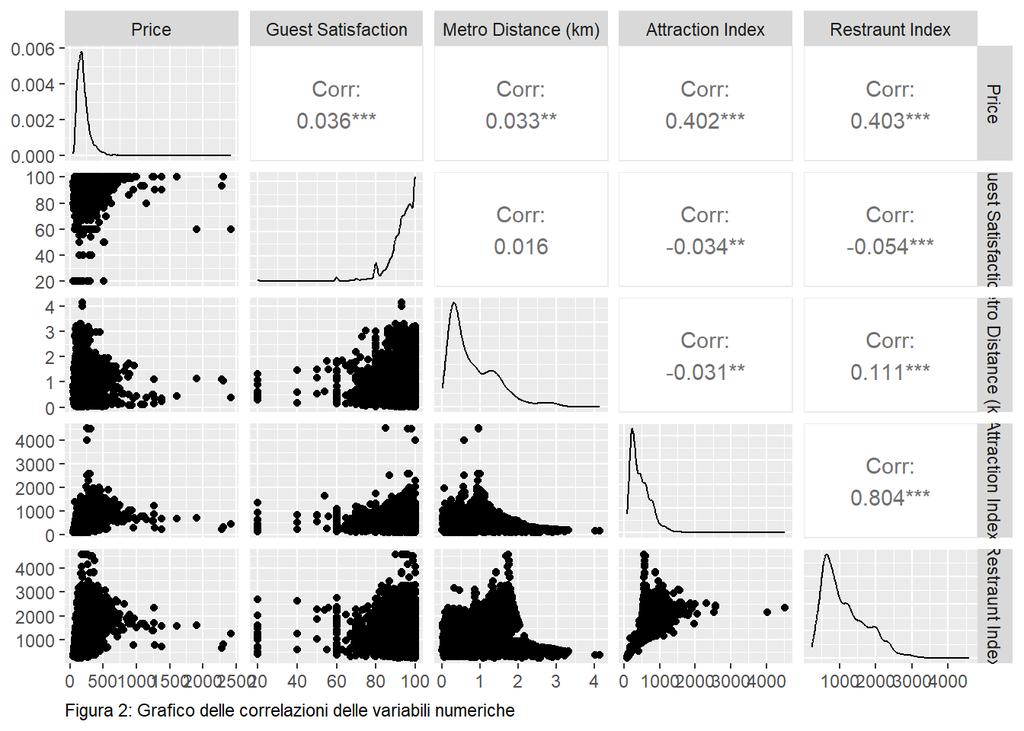

Durante l’analisi esplorativa, è utile selezionare alcune delle variabili categoriali presenti nel dataset per vedere come esse incidono sul prezzo degli airbnb.

Ad esempio prendiamo in considerazione la variabile categoriale Day e vediamo come varia la densità dei prezzi.

Dal grafico notiamo che le due densità sono molto simili, sembra che prenotare un airbnb durante il weekend o in settimana non incida di molto sul prezzo.

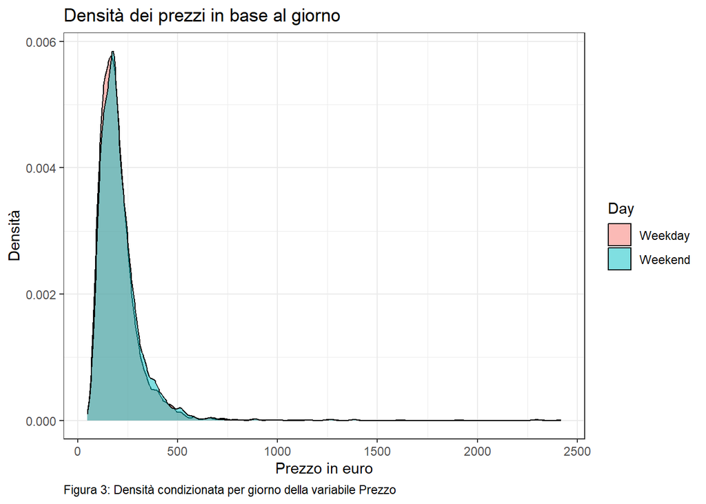

Infine prima di concludere l’analisi esplorativa dei dati, è utile anche analizzare il rapporto tra le varie variabili esplicative indipendenti presenti nel dataset.

Ad esempio prendiamo in considerazione le variabili categoriali Guest Satisfaction e Cleanliness Rating e vediamo come varia il Guest Satisfaction a seconda dei livello che la variabile categoriale Cleanliness Rating assume.

Dal grafico notiamo come Cleanliness Rating impatti sul Guest Satisfaction. Il Guest Satisfaction è maggiore per quegli airbnb le cui stanze sono pulite ed ordinate.

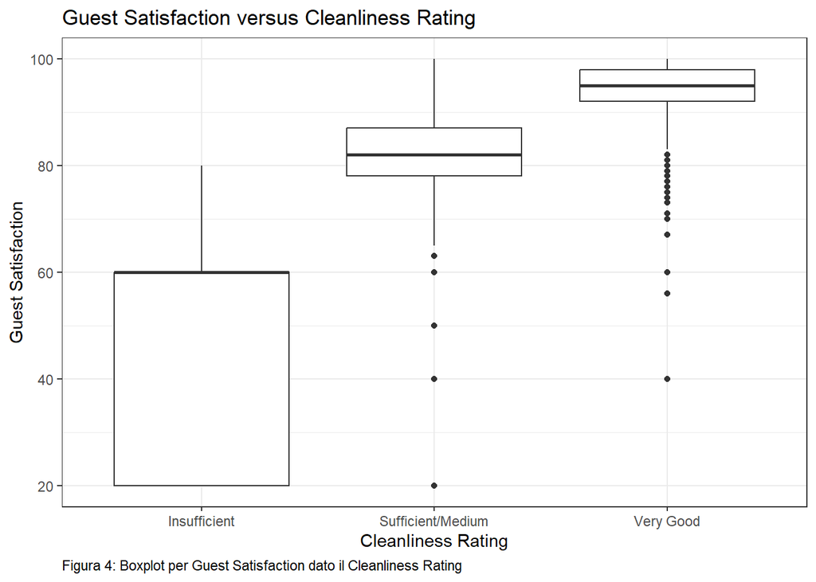

# Positive continuous data

Come abbiamo visto in precedenza, la distribuzione dei prezzi presenta alcune caratteristiche:

- Distribuzione continua non negativa.
- L’asimmetria è verso destra.

La distribuzione è asimmetrica positiva, la densità dei dati è maggiore a sinistra del valore mediano del prezzo, viceversa la densità dei dati a destra del valore mediano del prezzo è minore.

Prendendo in considerazione queste caratteristiche, prenderemo in considerazioni le sguenti distribuzioni:

- Distribuzione Gamma
- Distribuzione Guassiana Inversa

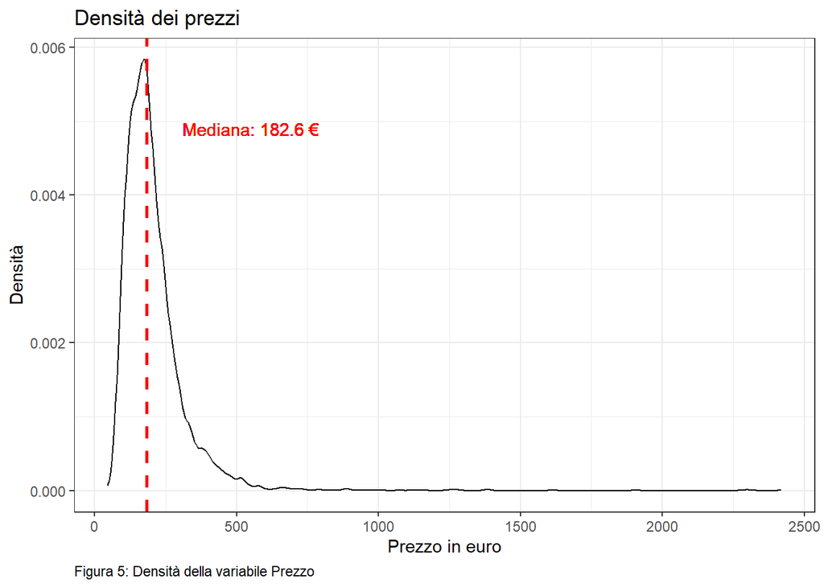

Innanzitutto dividiamo il dataset in training set e test set. Il training set è composto dall’80% delle osservazioni totali e verrà utilizzato per addestrare i vari modelli, Gamma regression e Inverse Gaussian regression, mentre il restante 20% farà parte del test set e verrà utilizzato per vedere quanto bene/male il modello in esame prevede la variabile dipendente prezzo.

La Gamma regression è un GLM (General linear model) in cui la componente casuale segue una distribuzione Gamma.

Per una più chiara interpretazione dei parametri del modello, verrà utilizzato il log-link.

L’obiettivo è quello di scegliere uno o più modelli contenenti solo quelle variabili esplicative che hanno un impatto statisticamente significativo sulla variabile dipendente prezzo.

Le performance predittive del modello verranno valutate grazie ai dati unseen del test set.

# Gamma regression

## Model selection

Consideriamo come primo modello, un modello completo contenente tutte le variabili esplicative indipendenti.

Come possiamo notare dal summary, in particolare dai p-value, non tutte le variabili esplicative sono statisticamente significative, non tutte hanno un impatto significativo sul prezzo.

Nel summary vengono riportate la Null deviance e la Residual Deviance.

La Null Deviance è data dalla differenza tra la log-likelihood del modello saturo e la log-likelihood del modello nullo. Se questa differenza è piccola, allora il modello da preferire per il principio di Parsimonia è quello nullo, ovvero il modello con solo l’intercetta $\beta_0$.

La Residual Deviance invece è data dalla differenza tra la log-likelihood del modello saturo e la log-likelihood del modello stimato.

```
##
## Call:
## glm(formula = Price ~ ., family = Gamma(link = log), data = train_set_airbnb_Rome_mescolato)
##
## Deviance Residuals:
##     Min       1Q   Median       3Q      Max
## -1.5823  -0.2311  -0.0693   0.1128   4.8997
##
## Coefficients:
##                                         Estimate Std. Error t value Pr(>|t|)
## (Intercept)                            4.825e+00  9.889e-02  48.793  < 2e-16
## DayWeekend                             3.417e-02  1.117e-02   3.060 0.002222
## `Room Type`Private room               -2.437e-01  1.584e-02 -15.382  < 2e-16
## `Room Type`Shared room                -6.280e-01  1.374e-01  -4.570 4.96e-06
## `Person Capacity`3                     3.943e-02  1.739e-02   2.267 0.023425
## `Person Capacity`>3                    1.271e-01  1.689e-02   7.525 5.89e-14
## SuperhostTRUE                         -1.304e-02  1.277e-02  -1.021 0.307432
## `Multiple Rooms`1                      1.311e-02  1.447e-02   0.906 0.364960
## Business1                              8.606e-03  1.562e-02   0.551 0.581570
## `Cleanliness Rating`Sufficient/Medium -3.775e-01  9.166e-02  -4.119 3.85e-05
## `Cleanliness Rating`Very Good         -4.472e-01  9.409e-02  -4.753 2.04e-06
## `Guest Satisfaction`                   5.347e-03  9.318e-04   5.738 9.96e-09
## Bedrooms1                              1.130e-01  3.314e-02   3.409 0.000656
## Bedrooms>1                             3.450e-01  3.538e-02   9.750  < 2e-16
## `City Center (km)`(3,6]               -1.048e-01  1.347e-02  -7.777 8.45e-15
## `City Center (km)`(6,10]              -1.395e-01  2.717e-02  -5.136 2.89e-07
## `Metro Distance (km)`                  3.003e-02  9.212e-03   3.260 0.001120
## `Attraction Index`                     5.574e-04  2.235e-05  24.936  < 2e-16
##
## (Intercept)                           ***
## DayWeekend                            **
## `Room Type`Private room               ***
## `Room Type`Shared room                ***
## `Person Capacity`3                    *
## `Person Capacity`>3                   ***
## SuperhostTRUE
## `Multiple Rooms`1
## Business1
## `Cleanliness Rating`Sufficient/Medium ***
## `Cleanliness Rating`Very Good         ***
## `Guest Satisfaction`                  ***
## Bedrooms1                             ***
## Bedrooms>1                            ***
## `City Center (km)`(3,6]               ***
## `City Center (km)`(6,10]              ***
## `Metro Distance (km)`                 **
## `Attraction Index`                    ***
## ---
## Signif. codes:  0 '***' 0.001 '**' 0.01 '*' 0.05 '.' 0.1 ' ' 1
##
## (Dispersion parameter for Gamma family taken to be 0.2246)
##
##     Null deviance: 1523.86  on 7220  degrees of freedom
## Residual deviance:  769.31  on 7203  degrees of freedom
## AIC: 79923
##
## Number of Fisher Scoring iterations: 7
```

Stimiamo un modello ridotto in cui escludiamo la variabile esplicativa che presenta il p-value maggiore, ovvero Business.

Possiamo confrontare il modello completo con il modello ridotto grazie al test LRT (Likelihood-Ratio-Test) in quanto si tratta di modelli NESTED.

Il p-value (0.5827) è maggiore del livello di significatività $\alpha$ fissato al 5%, quindi non possiamo rigettare l’ipotesi Nulla H0.

I due modelli sono equivalenti. Per il principio di parsimonia scegliamo il modello ristretto.

```
## Analysis of Deviance Table
##
## Model 1: Price ~ Day + `Room Type` + `Person Capacity` + Superhost + `Multiple Rooms` +
##     `Cleanliness Rating` + `Guest Satisfaction` + Bedrooms +
##     `City Center (km)` + `Metro Distance (km)` + `Attraction Index`
## Model 2: Price ~ Day + `Room Type` + `Person Capacity` + Superhost + `Multiple Rooms` +
##     Business + `Cleanliness Rating` + `Guest Satisfaction` +
##     Bedrooms + `City Center (km)` + `Metro Distance (km)` + `Attraction Index`
##   Resid. Df Resid. Dev Df Deviance Pr(>Chi)
## 1      7204     769.38
## 2      7203     769.31  1 0.067797   0.5827
```

Eseguiamo il test LRT (Likelihood-Ratio-Test) prendendo in considerazione il modello ridotto stimato in precedenza.

Aggiungendo una alla volta le varie variabili esplicative, notiamo come la devianza si riduca di molto quando all’interno del modello aggiungiamo una variabile che ha un impatto significativo sul prezzo, viceversa quando aggiungiamo all’interno del modello una variabile che non ha un impatto significativo sul prezzo, come ad esempio Superhost e Multiple Rooms, la devianza si riduce di poco.

Le variabili esplicative Superhost e Multiple Rooms non hanno un impatto significativo sul prezzo.

```
## Analysis of Deviance Table
##
## Model: Gamma, link: log
##
## Response: Price
##
## Terms added sequentially (first to last)
##
##
##                       Df Deviance Resid. Df Resid. Dev  Pr(>Chi)
## NULL                                   7220    1523.86
## Day                    1     3.99      7219    1519.87 2.419e-05 ***
## `Room Type`            2   373.17      7217    1146.70 < 2.2e-16 ***
## `Person Capacity`      2    58.89      7215    1087.81 < 2.2e-16 ***
## Superhost              1     0.21      7214    1087.60  0.331844
## `Multiple Rooms`       1     0.38      7213    1087.22  0.192749
## `Cleanliness Rating`   2     2.27      7211    1084.95  0.006247 **
## `Guest Satisfaction`   1     5.53      7210    1079.42 6.638e-07 ***
## Bedrooms               2    45.08      7208    1034.34 < 2.2e-16 ***
## `City Center (km)`     2   136.40      7206     897.94 < 2.2e-16 ***
## `Metro Distance (km)`  1     6.08      7205     891.87 1.870e-07 ***
## `Attraction Index`     1   122.48      7204     769.38 < 2.2e-16 ***
## ---
## Signif. codes:  0 '***' 0.001 '**' 0.01 '*' 0.05 '.' 0.1 ' ' 1
```

Prendendo in considerazione il modello stimato in precedenza, andiamo a stimare un’ulteriore modello in cui la variabile esplicativa Superhost è esclusa.

Dando uno sguardo ai p-value possiamo notare come tutte le variabili esplicative siano statisticamente significative ad eccezzione di Multiple Rooms.

La variabile esplicativa Multiple Rooms riduce di poco la devianza.

```
## Analysis of Deviance Table
##
## Model: Gamma, link: log
##
## Response: Price
##
## Terms added sequentially (first to last)
##
##
##                       Df Deviance Resid. Df Resid. Dev  Pr(>Chi)
## NULL                                   7220    1523.86
## Day                    1     3.99      7219    1519.87 2.535e-05 ***
## `Room Type`            2   373.17      7217    1146.70 < 2.2e-16 ***
## `Person Capacity`      2    58.89      7215    1087.81 < 2.2e-16 ***
## `Multiple Rooms`       1     0.32      7214    1087.49  0.230438
## `Cleanliness Rating`   2     2.09      7212    1085.40  0.009491 **
## `Guest Satisfaction`   1     5.97      7211    1079.42 2.547e-07 ***
## Bedrooms               2    45.08      7209    1034.35 < 2.2e-16 ***
## `City Center (km)`     2   136.40      7207     897.95 < 2.2e-16 ***
## `Metro Distance (km)`  1     6.08      7206     891.87 1.997e-07 ***
## `Attraction Index`     1   122.24      7205     769.63 < 2.2e-16 ***
## ---
## Signif. codes:  0 '***' 0.001 '**' 0.01 '*' 0.05 '.' 0.1 ' ' 1
```

Stimiamo un’ulteriore modello in cui la variabile esplicativa Multiple Rooms è esclusa.

Analizzando la devianza grazie al test LRT, notiamo come essa si riduce quando aggiungiamo una variabile esplicativa alla volta.

Tutte le variabili esplicative sono statisticamente significative.

Cleanliness Rating è significativa al 1%.

```
## Analysis of Deviance Table
##
## Model: Gamma, link: log
##
## Response: Price
##
## Terms added sequentially (first to last)
##
##
##                       Df Deviance Resid. Df Resid. Dev  Pr(>Chi)
## NULL                                   7220    1523.86
## Day                    1     3.99      7219    1519.87 2.492e-05 ***
## `Room Type`            2   373.17      7217    1146.70 < 2.2e-16 ***
## `Person Capacity`      2    58.89      7215    1087.81 < 2.2e-16 ***
## `Cleanliness Rating`   2     2.14      7213    1085.67  0.008508 **
## `Guest Satisfaction`   1     5.83      7212    1079.85 3.473e-07 ***
## Bedrooms               2    45.11      7210    1034.73 < 2.2e-16 ***
## `City Center (km)`     2   136.76      7208     897.98 < 2.2e-16 ***
## `Metro Distance (km)`  1     6.09      7207     891.89 1.913e-07 ***
## `Attraction Index`     1   122.17      7206     769.72 < 2.2e-16 ***
## ---
## Signif. codes:  0 '***' 0.001 '**' 0.01 '*' 0.05 '.' 0.1 ' ' 1
```

In definitiva, grazie al test LRT confrontiamo il modello completo stimato all’inizio con il modello ridotto in cui le variabili esplicative Business,Superhost e Multiple Rooms sono state escluse.

Il p-value (0.6105) è maggiore del livello di significatività $\alpha$ fissato al 5%, quindi non possiamo rigettare l’ipotesi Nulla H0.

I due modelli sono equivalenti. Per il principio di parsimonia scegliamo il modello ristretto.

```
## Analysis of Deviance Table
##
## Model 1: Price ~ Day + `Room Type` + `Person Capacity` + `Cleanliness Rating` +
##     `Guest Satisfaction` + Bedrooms + `City Center (km)` + `Metro Distance (km)` +
##     `Attraction Index`
## Model 2: Price ~ Day + `Room Type` + `Person Capacity` + Superhost + `Multiple Rooms` +
##     Business + `Cleanliness Rating` + `Guest Satisfaction` +
##     Bedrooms + `City Center (km)` + `Metro Distance (km)` + `Attraction Index`
##   Resid. Df Resid. Dev Df Deviance Pr(>Chi)
## 1      7206     769.72
## 2      7203     769.31  3  0.40882   0.6105
```

# Interpretazione dei coefficienti

Prendiamo in considerazione due variabili esplicative, una numerica continua e una di tipo categoriale.

**Metro Distance (km) = 3.1**

- Questa variabile esplicativa rappresenta la distanza (misurata in km) degli airbnb dalla metropolitana. Ceteris paribus, in media il prezzo degli airbnb aumenta del 3.1% quando la variabile esplicativa Metro Distance (km) subisce un incremento unitario.

**DayWeekend = 3.5**

- Questa variabile esplicativa rappresenta la prenotazione di un airbnb nel Weekend. Ceteris paribus, in media il prezzo degli airbnb durante il Weekend aumenta del 3.5% rispetto agli altri giorni della settimana.

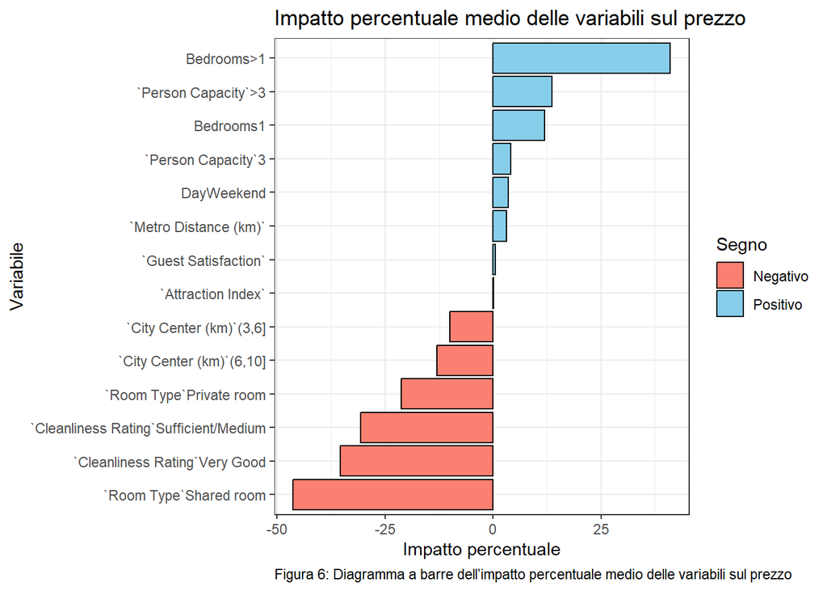

# Validazione

Ora, considerando il modello scelto addestrato sui dati di training, andiamo a prevedere il prezzo degli airbnb utilizzando il test set. Le metriche di performance prese in considerazione sono il Mean Squared Error, il Root Mean Squared Error e il Mean Absolute Error.

Queste metriche di performance verranno confrontate successivamente con le metriche di performance dell’altro modello scelto, in cui andremo a considerare la distribuzione Gaussiuana Inversa.

Tabella1: Metriche di performance per la regressione Gamma

| Metrica | Gamma |
| --- | --- |
| Mean Squared Error | 5489.81129 |
| Root Mean Squared Error | 74.09326 |
| Mean Absolute Error | 47.99991 |

# Inverse Gaussian regression

La Inverse Gaussian regression è un GLM (General linear model) in cui la componente casuale segue una distribuzione Gaussiana Inversa.

Per una più chiara interpretazione dei parametri del modello, verrà utilizzato il log-link.

## Model Selection

Consideriamo come primo modello, un modello completo contenente tutte le variabili esplicative indipendenti.

Come possiamo notare dal summary, in particolare dai p-value, non tutte le variabili esplicative sono statisticamente significative, non tutte hanno un impatto significativo sul prezzo.

In particolare, le variabili esplicative Superhost, Multiple Rooms e Business non sono statisticamente significative.

```
##
## Call:
## glm(formula = Price ~ ., family = inverse.gaussian(link = "log"),
##     data = train_set_airbnb_Rome_mescolato)
##
## Deviance Residuals:
##       Min         1Q     Median         3Q        Max
## -0.100363  -0.017223  -0.005092   0.007758   0.315924
##
## Coefficients:
##                                         Estimate Std. Error t value Pr(>|t|)
## (Intercept)                            4.758e+00  1.032e-01  46.120  < 2e-16
## DayWeekend                             3.572e-02  1.139e-02   3.135 0.001725
## `Room Type`Private room               -2.458e-01  1.581e-02 -15.549  < 2e-16
## `Room Type`Shared room                -6.131e-01  1.010e-01  -6.068 1.36e-09
## `Person Capacity`3                     3.981e-02  1.668e-02   2.387 0.017002
## `Person Capacity`>3                    1.161e-01  1.728e-02   6.716 2.01e-11
## SuperhostTRUE                         -1.800e-02  1.308e-02  -1.376 0.168821
## `Multiple Rooms`1                      8.596e-03  1.491e-02   0.577 0.564210
## Business1                             -1.734e-02  1.637e-02  -1.059 0.289476
## `Cleanliness Rating`Sufficient/Medium -2.672e-01  9.645e-02  -2.770 0.005611
## `Cleanliness Rating`Very Good         -3.255e-01  9.877e-02  -3.296 0.000986
## `Guest Satisfaction`                   4.191e-03  9.078e-04   4.617 3.96e-06
## Bedrooms1                              1.162e-01  3.332e-02   3.486 0.000493
## Bedrooms>1                             3.384e-01  3.651e-02   9.269  < 2e-16
## `City Center (km)`(3,6]               -6.905e-02  1.381e-02  -5.001 5.83e-07
## `City Center (km)`(6,10]              -7.454e-02  2.584e-02  -2.884 0.003935
## `Metro Distance (km)`                  2.851e-02  9.276e-03   3.074 0.002121
## `Attraction Index`                     6.751e-04  2.917e-05  23.140  < 2e-16
##
## (Intercept)                           ***
## DayWeekend                            **
## `Room Type`Private room               ***
## `Room Type`Shared room                ***
## `Person Capacity`3                    *
## `Person Capacity`>3                   ***
## SuperhostTRUE
## `Multiple Rooms`1
## Business1
## `Cleanliness Rating`Sufficient/Medium **
## `Cleanliness Rating`Very Good         ***
## `Guest Satisfaction`                  ***
## Bedrooms1                             ***
## Bedrooms>1                            ***
## `City Center (km)`(3,6]               ***
## `City Center (km)`(6,10]              **
## `Metro Distance (km)`                 **
## `Attraction Index`                    ***
## ---
## Signif. codes:  0 '***' 0.001 '**' 0.01 '*' 0.05 '.' 0.1 ' ' 1
##
## (Dispersion parameter for inverse.gaussian family taken to be 0.001256877)
##
##     Null deviance: 7.5103  on 7220  degrees of freedom
## Residual deviance: 3.7264  on 7203  degrees of freedom
## AIC: 79023
##
## Number of Fisher Scoring iterations: 6
```

Stimiamo un modello ridotto in cui escludiamo la variabile esplicativa che presenta il p-value maggiore, ovvero Multiple Rooms.

Possiamo confrontare il modello completo stimato in precedenza con il modello ridotto grazie al test LRT (Likelihood-Ratio-Test) in quanto si tratta di modelli NESTED.

Il p-value (0.5644) è maggiore del livello di significatività $\alpha$ fissato al 5%, quindi non possiamo rigettare l’ipotesi Nulla H0.

I due modelli sono equivalenti. Per il principio di parsimonia scegliamo il modello ristretto.

```
## Analysis of Deviance Table
##
## Model 1: Price ~ Day + `Room Type` + `Person Capacity` + Superhost + Business +
##     `Cleanliness Rating` + `Guest Satisfaction` + Bedrooms +
##     `City Center (km)` + `Metro Distance (km)` + `Attraction Index`
## Model 2: Price ~ Day + `Room Type` + `Person Capacity` + Superhost + `Multiple Rooms` +
##     Business + `Cleanliness Rating` + `Guest Satisfaction` +
##     Bedrooms + `City Center (km)` + `Metro Distance (km)` + `Attraction Index`
##   Resid. Df Resid. Dev Df  Deviance Pr(>Chi)
## 1      7204     3.7268
## 2      7203     3.7264  1 0.0004175   0.5644
```

Eseguiamo il test LRT (Likelihood-Ratio-Test) prendendo in considerazione il modello ridotto stimato in precedenza.

Le variabili esplicative Superhost e Cleanliness Rating non hanno un impatto significativo sul prezzo.

```
## Analysis of Deviance Table
##
## Model: inverse.gaussian, link: log
##
## Response: Price
##
## Terms added sequentially (first to last)
##
##
##                       Df Deviance Resid. Df Resid. Dev  Pr(>Chi)
## NULL                                   7220     7.5103
## Day                    1  0.01935      7219     7.4910 8.259e-05 ***
## `Room Type`            2  1.93924      7217     5.5517 < 2.2e-16 ***
## `Person Capacity`      2  0.26967      7215     5.2821 < 2.2e-16 ***
## Superhost              1  0.00238      7214     5.2797    0.1672
## Business               1  0.06090      7213     5.2188 2.858e-12 ***
## `Cleanliness Rating`   2  0.00571      7211     5.2131    0.1017
## `Guest Satisfaction`   1  0.04560      7210     5.1675 1.501e-09 ***
## Bedrooms               2  0.18885      7208     4.9786 < 2.2e-16 ***
## `City Center (km)`     2  0.56337      7206     4.4152 < 2.2e-16 ***
## `Metro Distance (km)`  1  0.03197      7205     4.3833 4.182e-07 ***
## `Attraction Index`     1  0.65651      7204     3.7268 < 2.2e-16 ***
## ---
## Signif. codes:  0 '***' 0.001 '**' 0.01 '*' 0.05 '.' 0.1 ' ' 1
```

Prendendo in considerazione il modello stimato in precedenza, andiamo a stimare un’ulteriore modello in cui la variabile esplicativa Superhost è esclusa.

Con il test LRT confrontiamo il modello completo con il modello ridotto in cui le variabili esplicative Multiple Rooms e Superhost sono state escluse.

Il p-value (0.337) è maggiore del livello di significatività $\alpha$ fissato al 5%, quindi non rigettiamo l’ipotesi nulla H0. I due modelli sono equivalenti.

Per il principio di parsimonia scegliamo il modello ristretto.

```
## Analysis of Deviance Table
##
## Model 1: Price ~ Day + `Room Type` + `Person Capacity` + Superhost + `Multiple Rooms` +
##     Business + `Cleanliness Rating` + `Guest Satisfaction` +
##     Bedrooms + `City Center (km)` + `Metro Distance (km)` + `Attraction Index`
## Model 2: Price ~ Day + `Room Type` + `Person Capacity` + Business + `Cleanliness Rating` +
##     `Guest Satisfaction` + Bedrooms + `City Center (km)` + `Metro Distance (km)` +
##     `Attraction Index`
##   Resid. Df Resid. Dev Df   Deviance Pr(>Chi)
## 1      7203     3.7264
## 2      7205     3.7291 -2 -0.0027342    0.337
```

Eseguiamo il test LRT (Likelihood-Ratio-Test) prendendo in considerazione il modello ridotto stimato in precedenza.

In questo caso dando uno sguardo ai p-value notiamo che tutte le variabili esplicative sono statisticamente significative ad eccezzione di Cleanliness Rating.

```
## Analysis of Deviance Table
##
## Model: inverse.gaussian, link: log
##
## Response: Price
##
## Terms added sequentially (first to last)
##
##
##                       Df Deviance Resid. Df Resid. Dev  Pr(>Chi)
## NULL                                   7220     7.5103
## Day                    1  0.01935      7219     7.4910 9.075e-05 ***
## `Room Type`            2  1.93924      7217     5.5517 < 2.2e-16 ***
## `Person Capacity`      2  0.26967      7215     5.2821 < 2.2e-16 ***
## Business               1  0.05834      7214     5.2237 1.070e-11 ***
## `Cleanliness Rating`   2  0.00505      7212     5.2187    0.1355
## `Guest Satisfaction`   1  0.05069      7211     5.1680 2.359e-10 ***
## Bedrooms               2  0.18839      7209     4.9796 < 2.2e-16 ***
## `City Center (km)`     2  0.56430      7207     4.4153 < 2.2e-16 ***
## `Metro Distance (km)`  1  0.03161      7206     4.3837 5.648e-07 ***
## `Attraction Index`     1  0.65459      7205     3.7291 < 2.2e-16 ***
## ---
## Signif. codes:  0 '***' 0.001 '**' 0.01 '*' 0.05 '.' 0.1 ' ' 1
```

Infine, prendendo in considerazione il modello stimato in precedenza, andiamo a stimare un’ulteriore modello in cui la variabile esplicativa Cleanliness Rating è esclusa.

```
##
## Call:
## glm(formula = Price ~ ., family = inverse.gaussian(link = "log"),
##     data = subset(train_set_airbnb_Rome_mescolato, select = -c(Superhost,
##         `Multiple Rooms`, `Cleanliness Rating`)))
##
## Deviance Residuals:
##      Min        1Q    Median        3Q       Max
## -0.09182  -0.01721  -0.00517   0.00761   0.31747
##
## Coefficients:
##                            Estimate Std. Error t value Pr(>|t|)
## (Intercept)               4.631e+00  7.596e-02  60.969  < 2e-16 ***
## DayWeekend                3.583e-02  1.154e-02   3.104 0.001914 **
## `Room Type`Private room  -2.442e-01  1.553e-02 -15.722  < 2e-16 ***
## `Room Type`Shared room   -6.125e-01  1.023e-01  -5.989 2.21e-09 ***
## `Person Capacity`3        3.694e-02  1.686e-02   2.191 0.028508 *
## `Person Capacity`>3       1.155e-01  1.746e-02   6.614 4.00e-11 ***
## Business1                -2.451e-02  1.308e-02  -1.874 0.060904 .
## `Guest Satisfaction`      2.157e-03  7.096e-04   3.040 0.002377 **
## Bedrooms1                 1.135e-01  3.377e-02   3.362 0.000778 ***
## Bedrooms>1                3.397e-01  3.698e-02   9.187  < 2e-16 ***
## `City Center (km)`(3,6]  -7.269e-02  1.397e-02  -5.202 2.02e-07 ***
## `City Center (km)`(6,10] -8.003e-02  2.616e-02  -3.060 0.002224 **
## `Metro Distance (km)`     3.049e-02  9.364e-03   3.257 0.001133 **
## `Attraction Index`        6.703e-04  2.938e-05  22.812  < 2e-16 ***
## ---
## Signif. codes:  0 '***' 0.001 '**' 0.01 '*' 0.05 '.' 0.1 ' ' 1
##
## (Dispersion parameter for inverse.gaussian family taken to be 0.001289358)
##
##     Null deviance: 7.5103  on 7220  degrees of freedom
## Residual deviance: 3.7488  on 7207  degrees of freedom
## AIC: 79059
##
## Number of Fisher Scoring iterations: 8
```

# Interpretazione dei coefficienti

Prendiamo in considerazione due variabili esplicative, una numerica continua e una di tipo categoriale.

**Metro Distance (km) = 3.09**

- Ceteris paribus, in media il prezzo degli airbnb aumenta del 3% quando la variabile esplicativa Metro Distance (km) subisce un incremento unitario. In precedenza tale variazione in media ammontava al 3.1%.

**DayWeekend = 3.64**

- Ceteris paribus, in media il prezzo degli airbnb durante il Weekend aumenta del 3.64% rispetto agli altri giorni della settimana. In precedenza tale variazione in media ammontava al 3.5%.

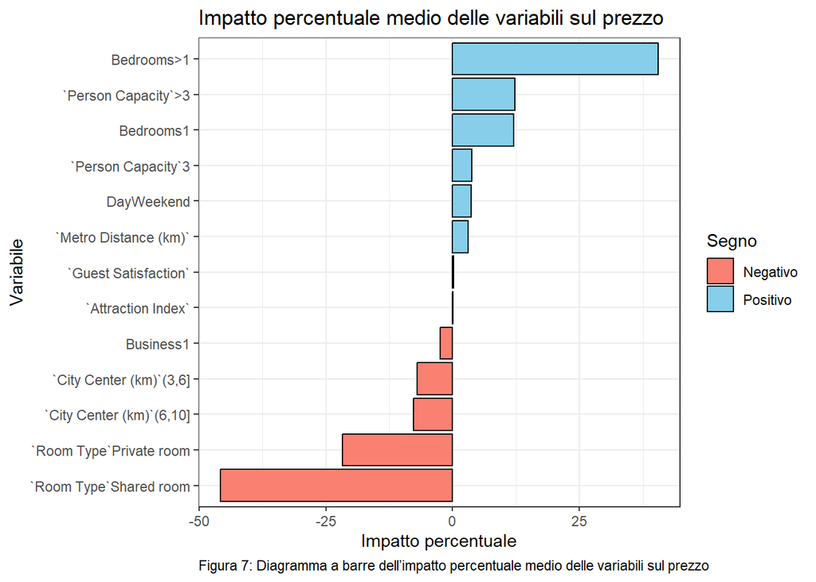

# Validazione

Considerando il modello scelto addestrato sui dati di training, andiamo a prevedere il prezzo degli airbnb utilizzando il test set.

Qui confronteremo le metriche di performance dei due modelli scelti.

Dal grafico notiamo che le previsioni dei due modelli considerati sono molto simili tra loro.

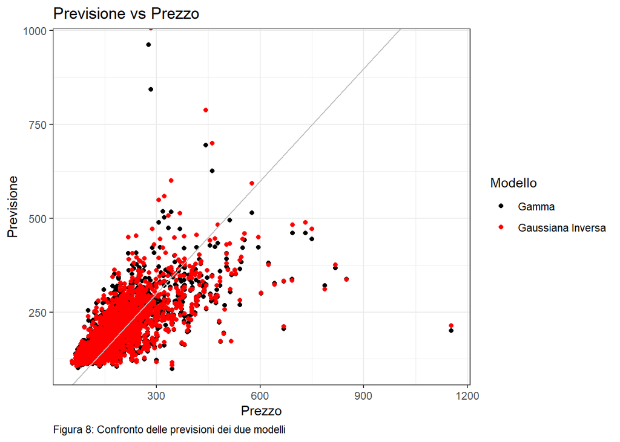

Come possiamo notare dalla tabella, la Gamma regression presenta delle metriche di performance un pò più accurate.

Tabella2: Metriche di performance per la regressione Gamma e Inversa Gaussiana

| Metrica | Gamma | Gaussiana_Inversa |
| --- | --- | --- |
| Mean Squared Error | 5489.81129 | 5861.15552 |
| Root Mean Squared Error | 74.09326 | 76.55818 |
| Mean Absolute Error | 47.99991 | 48.19546 |

# Marginal effects

Utilizziamo il modello stimato con la Gamma regression per calcolare gli effetti marginali.

Consideriamo alcune variabili categoriali che possono influenzare il prezzo di un airbnb, ad esempio il numero di camere da letto.

Più camere da letto ci sono, maggiore è il prezzo previsto.

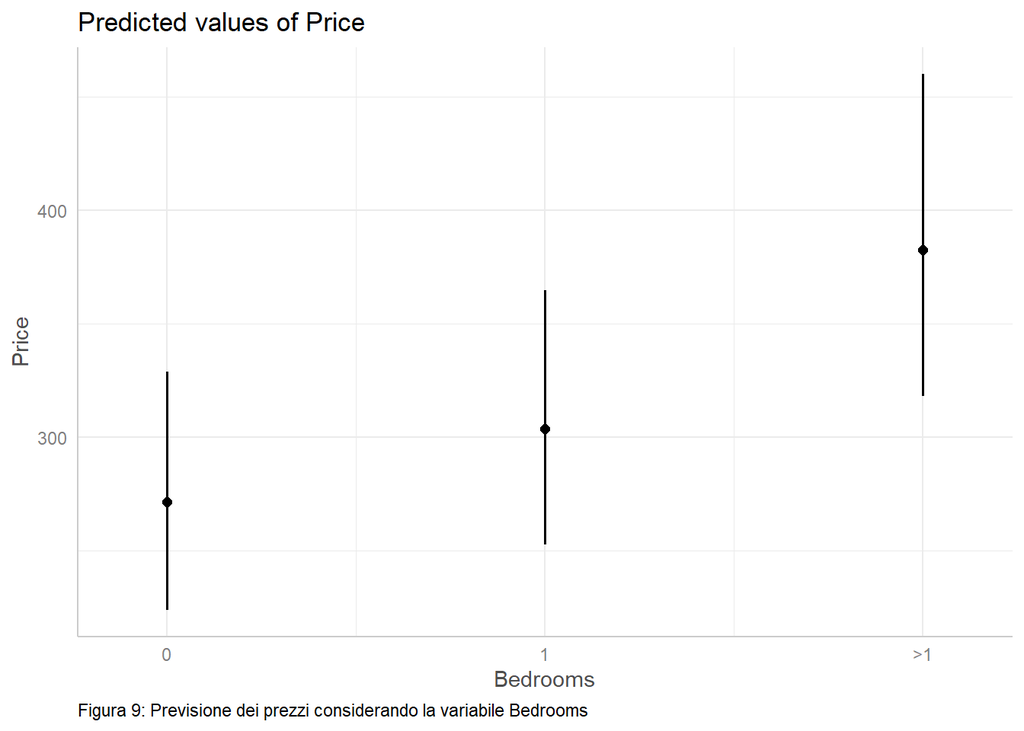

Consideriamo ora le variabili categoriali Room Type e Day.

Ovviamente il prezzo previsto sarà maggiore per “entire home”, ovvero quando l’ospite avrà l’accesso esclusivo e privato a tutta la casa o all’appartamento durante il soggiorno.

I prezzi previsti risultano un pò più alti quando prenotiamo un airbnb durante il weekend.

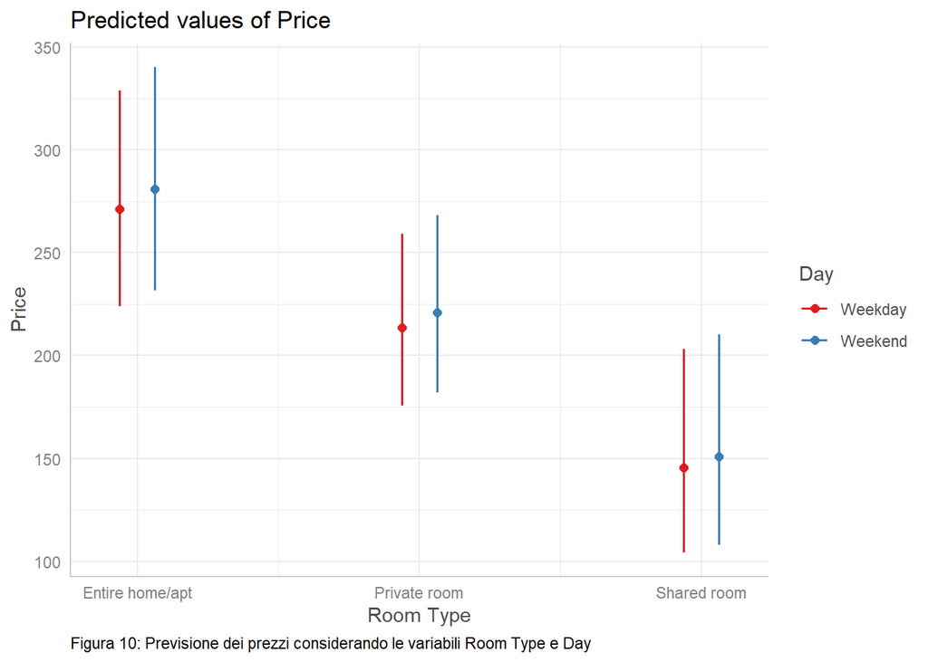